# R 그래픽스

### 03.1 그래픽 기초

1. 고수준 그래픽 함수의 공통 옵션 add=FALSE/TRUE axes=TRUE/FALSE type= “p” : points(점)  
   “l” : lines(선)  
   “b” : both(points+lines)  
   “o” : “b”와 유사하나 선이 점을 통과(over)  
   “h” : histogram-like  
   “s” : stair steps, “S” : “s”와 유사하나 다른 계단  
   “n” : no plotting  
   main=“제목”, sub=“부제목”  
   xlim=c(min,max), ylim=c(min,max) : x, y 축의 범위 지정  
   xlab=“x축 이름”, ylab=“y축 이름”  
   asp= # 축의 가로와 세로 비율

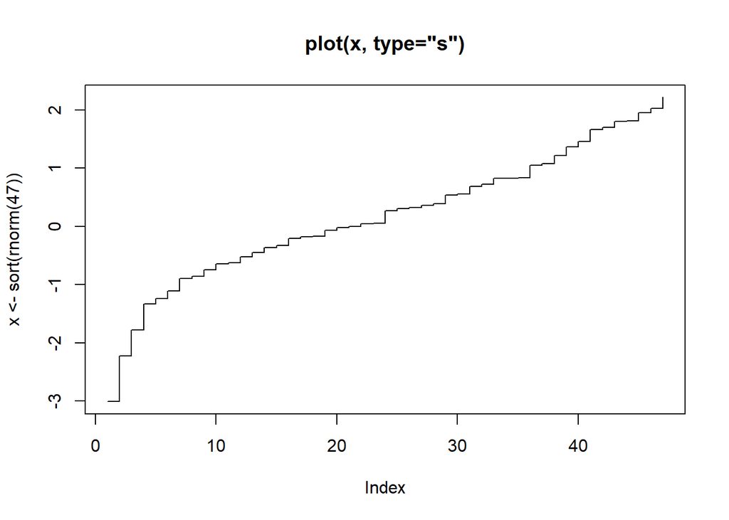

```r
## 그래픽 옵션 사용 예
plot(x <- sort(rnorm(47)), type="s", main="plot(x, type=\"s\")")
```

(b) 고수준 그래픽 선택 옵션  
- 선(line)과 점(point)  
lty= : 선의 형태(line type), 0~6 사이의 숫자(또는 대응 문자열로 지정)  
0=blank, 1=solid, 2=dashed, 3=dotted, 4=dotdash, 5=longdash, 6=twodash  
lwd=1 : 선의 너비, 디폴트는 1  
pch= : 점의 형태, 0~25 사이의 숫자로 지정  
21~25에 대해서는 테두리 생상을 지정할 수 있고(col=), 내부를 다른 색으로 채울 수도 있음(bg=)

- 문자 크기  
  cex= : 문자(점)의 높이(크기) 지정  
  ps= : 텍스트의 점 크기
- 색  
  col= : 선 또는 점의 색을 지정, 색의 종류는 colors() 함수 이용  
  bg= : 배경 색
- 다중 플롯을 위한 그림 배열  
  mfcol=c(행의 수, 열의 수) : 다중 플롯의 그림 배열, 열 우선으로 그림  
  mfrow=c(행의 수, 열의 수) : 다중 플롯의 그림 배열, 행 우선으로 그림
- 그림의 여백  
  mar= : 문장 라인의 수로 여백을 지정  
  (밑, 좌, 위, 우)순서, 디폴트=(5.1, 4.1, 4.1, 2.1)  
  mai= : 인치로 여백의 크기 지정, (밑, 좌, 위, 우)의 순서  
  mex= : 여백에서 축의 문자 크기 확장  
  oma=, omd=, omi= : 그림의 외부 여백 크기
- 축 관련  
  tck=, tcl= : 축의 눈금의 길이  
  xaxt=, yaxt= : x(또는 y)축의 형태
- 형태  
  bty= : 테두리 박스 형태  
  “o”: 디폴트, “l”: L형, “7”: ㄱ형, “]”: ]형  
  pty= : 플롯 형태
- 문자의 폰트  
  font= : 문자의 폰트 지정  
  1: normal, 2: italics, 3: bold, 4: bold italics
- 축의 라벨 스타일  
  las= : 0:축과 평행, 1: 수평, 2: 축과 직교, 3: 수직
- 축의 스케일  
  xlog, ylog= FALSE/TRUE : TRUE의 경우 log 스케일이 적용됨

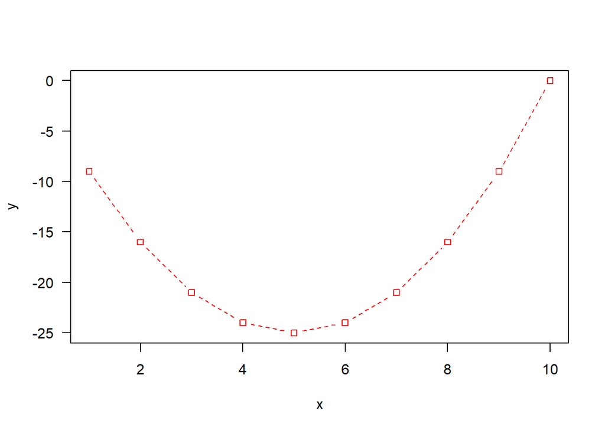

```r
## 그래픽 옵션의 사용 예
x <- seq(1,10)
y <- x^2-10*x
plot(x, y, type="both", pch=22, lty=2, col="red", las=1)
```

```r
# 옵션들의 적용 결과를 아래 그림에서 확인해볼 것
```

### 03.2 고수준 그래픽 함수

```r
## iris 자료를 이용한 고수준 그래픽 함수의 적용 예
attach(iris)
str(iris)
```

```
## 'data.frame':    150 obs. of  5 variables:
##  $ Sepal.Length: num  5.1 4.9 4.7 4.6 5 5.4 4.6 5 4.4 4.9 ...
##  $ Sepal.Width : num  3.5 3 3.2 3.1 3.6 3.9 3.4 3.4 2.9 3.1 ...
##  $ Petal.Length: num  1.4 1.4 1.3 1.5 1.4 1.7 1.4 1.5 1.4 1.5 ...
##  $ Petal.Width : num  0.2 0.2 0.2 0.2 0.2 0.4 0.3 0.2 0.2 0.1 ...
##  $ Species     : Factor w/ 3 levels "setosa","versicolor",..: 1 1 1 1 1 1 1 1 1 1 ...
```

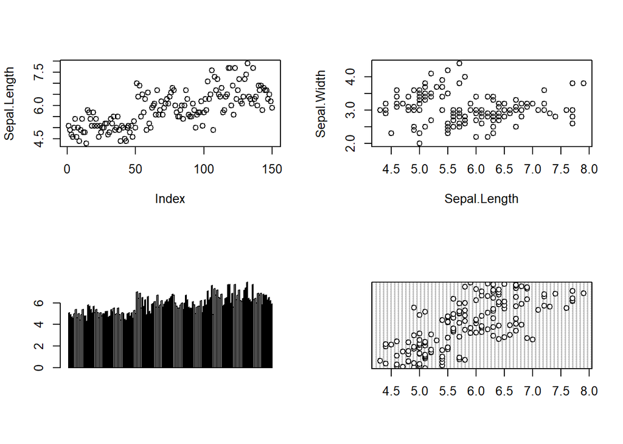

```r
## par() 함수는 전역적으로 그래픽 옵션을 설정하는 함수임
par(mfrow=c(2,2))  # 2*2 행렬 형태의 다중 패널 플롯을 설정함
plot(Sepal.Length)
plot(Sepal.Length, Sepal.Width)
barplot(Sepal.Length)
dotchart(Sepal.Length)
```

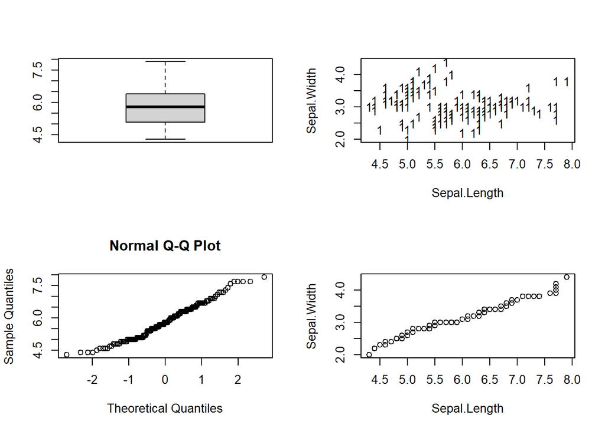

```r
boxplot(Sepal.Length)
matplot(Sepal.Length, Sepal.Width)
qqnorm(Sepal.Length)
qqplot(Sepal.Length, Sepal.Width)
```

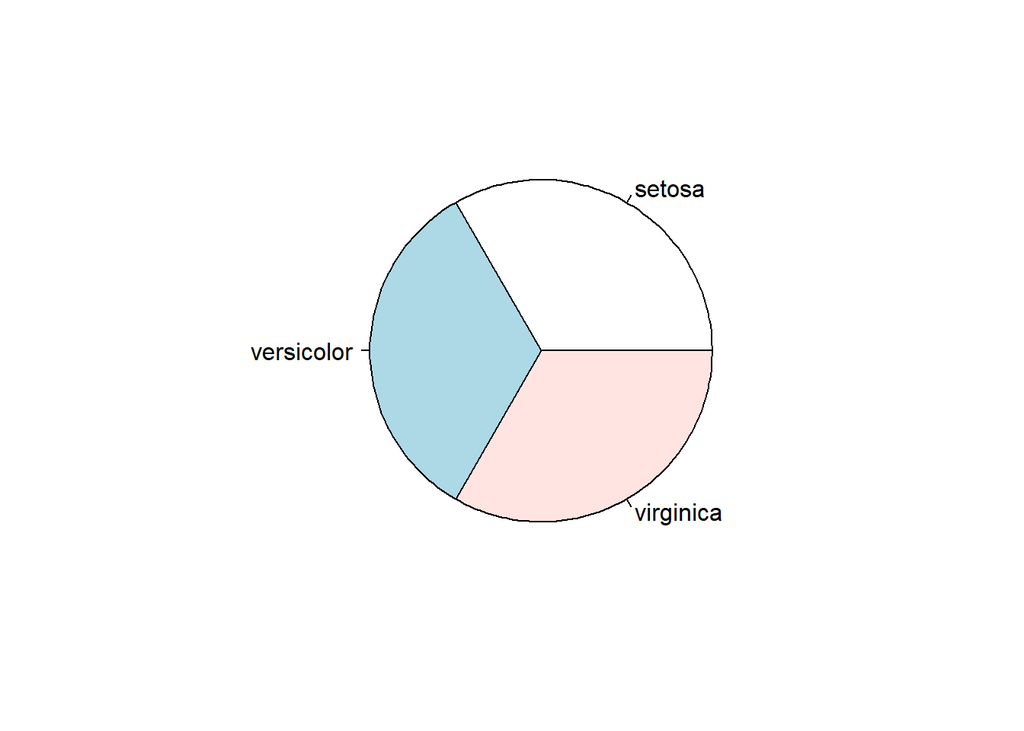

```r
par(mfrow=c(1,1))  # 다중 패널 플롯 옵션을 원상태로 돌림

pie(table(iris$Species))
```

### 03.3 저수준 그래픽 함수

- 1. 점, 선 추가 함수  
     points() : 점 추가  
     lines() : 선 추가  
     locator() : 커서로 지정한 위치에 점(또는 선)을 추가
- 2. 직선, 화살표, 문자, 축에 텍스트 추가 함수  
     abline() : 직선 추가  
     arrow() : 화살표 추가  
     text() : 문자 추가  
     mtext() : 마진의 4면에 텍스트 추가
- 3. 제목, 범례, 축의 눈금자, 융단 함수  
     title() : 제목 추가  
     legend() : 범례 추가  
     axis() : 축의 눈금자 추가  
     rug() : 융단 추가
- 4. 사각형, 다각형 함수  
     rect() : 사각형 추가  
     polygon() : 다각형 추가

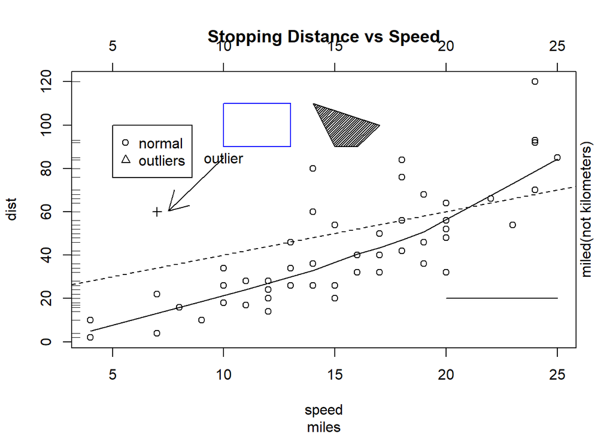

```r
#(a)
attach(cars)
plot(speed, dist)
points(7, 60, pch=3)
lines(c(20, 25), c(20, 20))
lines(lowess(speed, dist))
locator(2, type="p", pch=8)

#(b)
locator(2, type="l");
abline(a=20, b=2, lty=2)
arrows(10, 85, 7.5, 60.5)
text(10, 85, "outlier")
mtext("miled(not kilometers)", side=4)

#(c)
title(main="Stopping Distance vs Speed", sub="miles")
legend(5, 100, c("normal", "outliers"), pch=c(1,2))
axis(3)
rug(dist, side=2)

#(d)
rect(10, 110, 13, 90, border="blue")
polygon(c(14, 15, 16, 17), c(110, 90, 90, 100), density=50)
locator(2, type="p", pch=8)
locator(2, type="l")
```

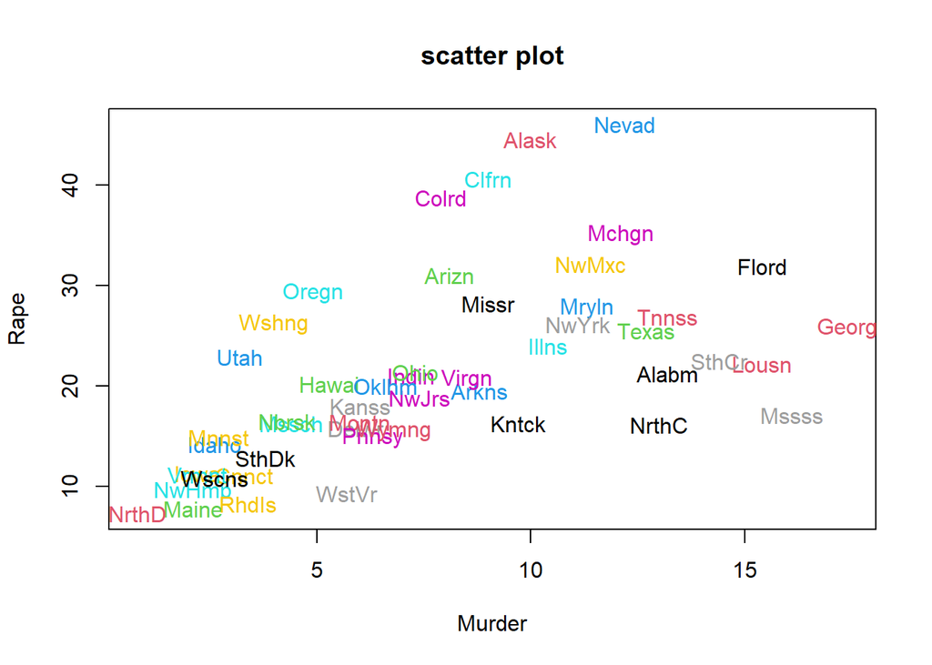

```r
## 저수준 그래픽 함수의 활용 예
statename=abbreviate(rownames(USArrests), 5)  # 주 이름 요약
plot(USArrests$Murder, USArrests$Rape, xlab="Murder", ylab="Rape", main="scatter plot", type="n")
text(USArrests$Murder, USArrests$Rape, labels=statename, cex=1.0, col=1:50)
```

### 03.4 유용한 그래픽 예제

##### 03.4.1 데이터에 잡음 넣기와 밀도 그림

- 1. 데이터에 잡음 넣기 jitter()

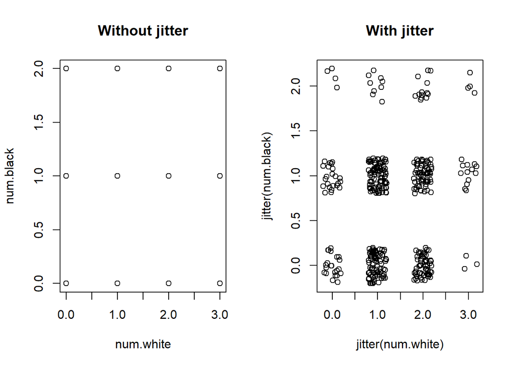

```r
num.white <- rhyper(400, 4, 5, 3)  # 초기하분포로부터 400개의 난수 발생
num.black <- rhyper(400, 2, 7, 3)
par(mfrow=c(1,2))
plot(num.white, num.black, main="Without jitter")
plot(jitter(num.white), jitter(num.black), main="With jitter")
```

```r
par(mfrow=c(1,1))
```

-(b) 밀도 그림

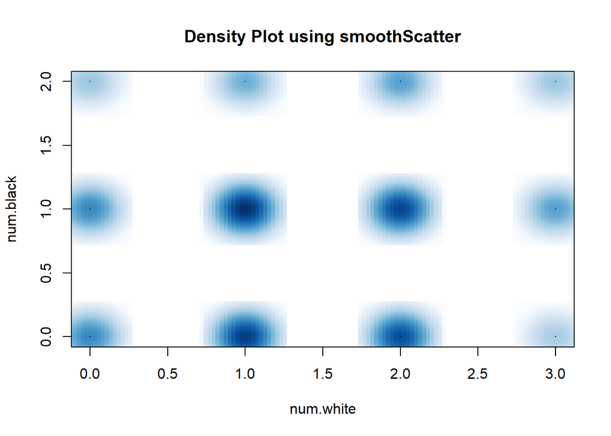

```r
smoothScatter(num.white, num.black, main="Density Plot using smoothScatter")
```

##### 03.4.2 그래프에 음영 영역 지정 -(a) 그림에 음영 영역 추가 : polygon() 함수의 적용 예

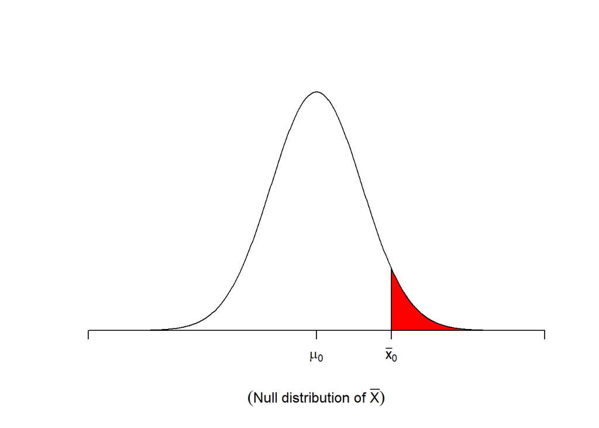

```r
x <- seq(-5, 5, by=0.01)
y <- dnorm(x)
upper <- qnorm(0.95)
plot(x, y, type="l", xaxt="n", ylab="",
     xlab=expression((paste('Null distribution of ', bar(X)))),
     axes=FALSE, ylim=c(0, max(y)*1.05), xlim = c(min(x), max(x)),
     frame.plot = FALSE)
axis(1, at=c(-5, 0, upper, 5),  # 아래  labes= 의 길이와 같아야 함
     pos=c(0,0),  # 축 선이 그려질 위치를 지정
     labels = c(" ", expression(mu[0]), expression(bar(x)[0]), " " ))
      # > axis(2)  # 실행 시 y 축이 추가됨
x.reg <- seq(upper, 5, by=0.01)
y.reg <- dnorm(x.reg)
polygon(c(x.reg, x.reg[length(x.reg)], x.reg[1]),
        c(y.reg, 0, 0), col="red")
```

-(b) 산점도의 테두리 영역 지정 : cull() 함수 이용용

[output not shown]

[output not shown]

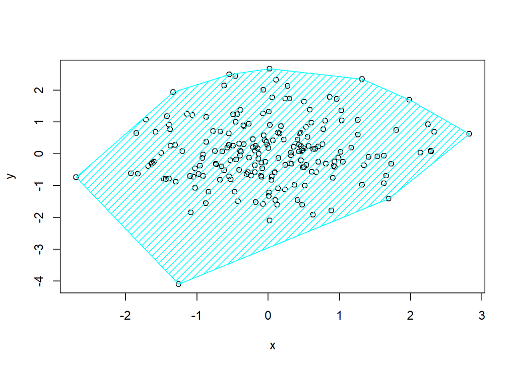

```r
x <- rnorm(200)
y <- rnorm(200)
h <- chull(x, y)
plot(x, y)
polygon(x[h], y[h], dens=15, angel=30, col="cyan")
```

### 03.5 격자 그래픽

##### 03.5.1 기본 함수

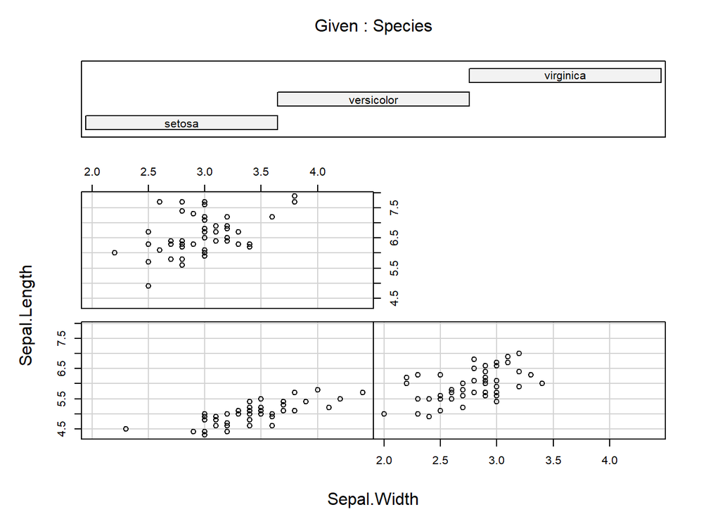

```r
coplot(Sepal.Length ~ Sepal.Width | Species)  # 조건부 그림
```

##### 03.5.2 패키지 {lattice}의 함수

- {lattice} 주요 함수

```r
#install.packages("lattice")
library("lattice")
attach(iris)
```

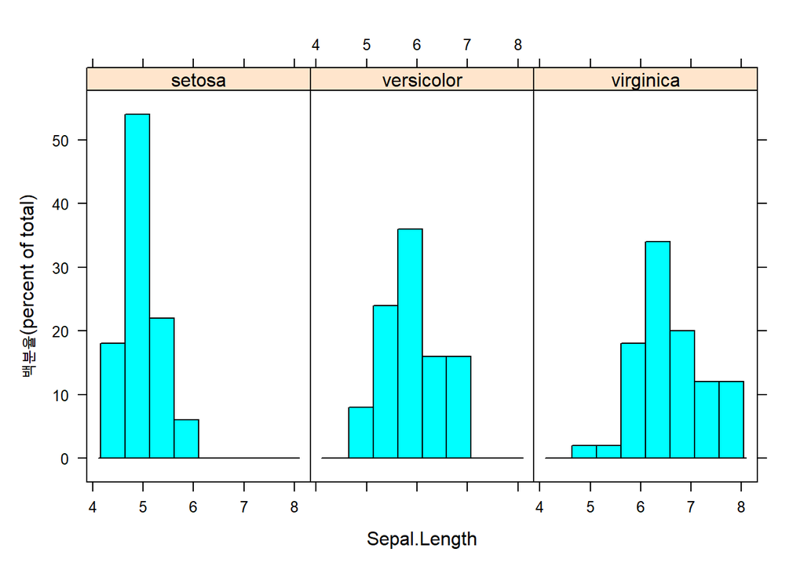

```r
# 히스토그램
histogram(~Sepal.Length | Species)
```

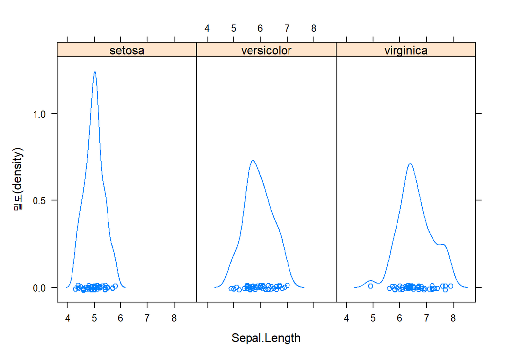

```r
# 밀도 그림
densityplot(~Sepal.Length | Species)
```

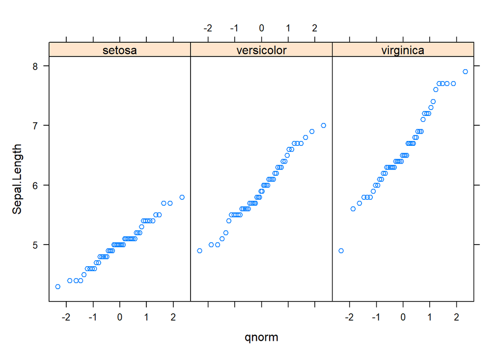

```r
# 분위수-분위수 그림
qqmath(~Sepal.Length | Species)
```

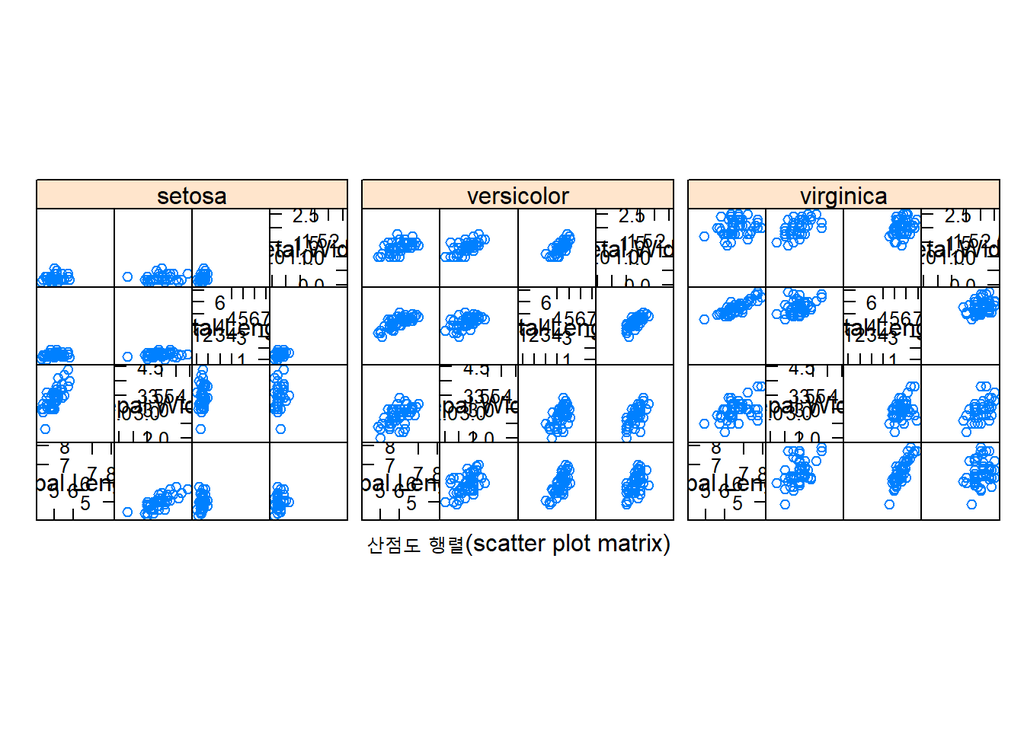

```r
# 산점도 행렬
splom(~iris[1:4] | Species)
```

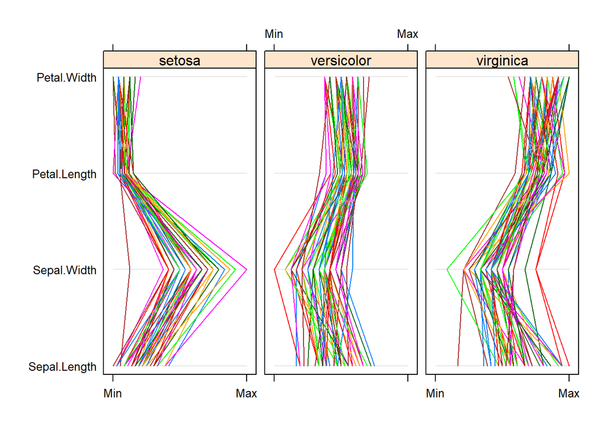

```r
# 평행 좌표 그림
parallelplot(~iris[1:4] | Species)
```

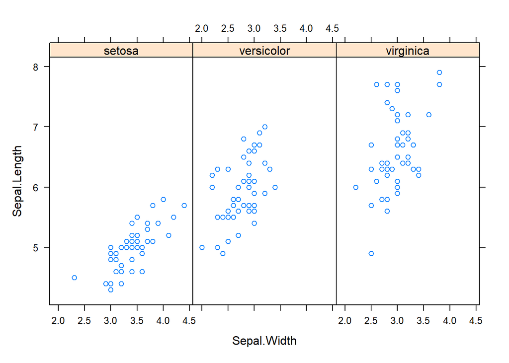

```r
# xy 플롯
xyplot(Sepal.Length~Sepal.Width | Species)
```

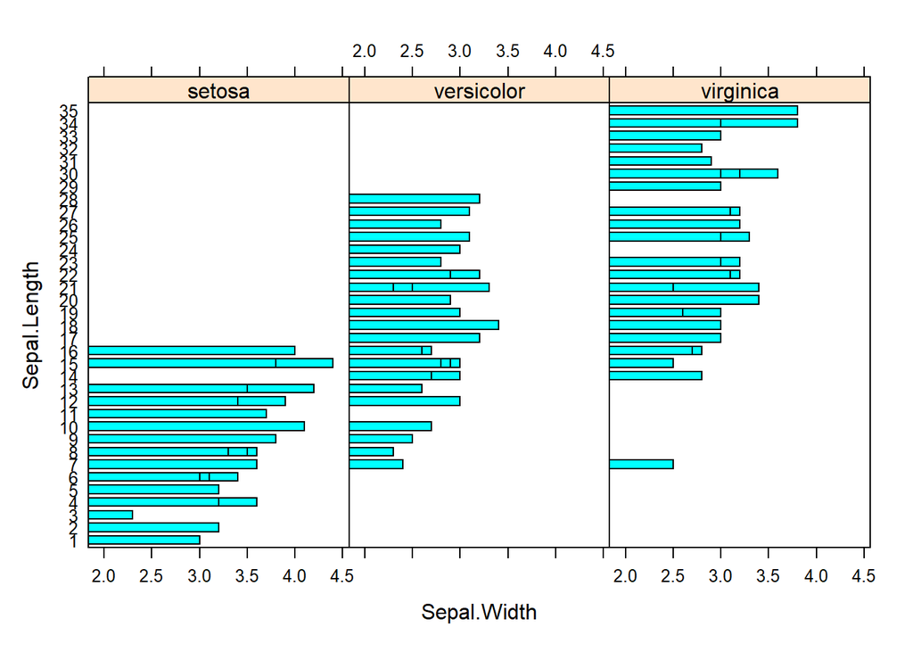

```r
# 막대 차트
barchart(Sepal.Length~Sepal.Width | Species)
```

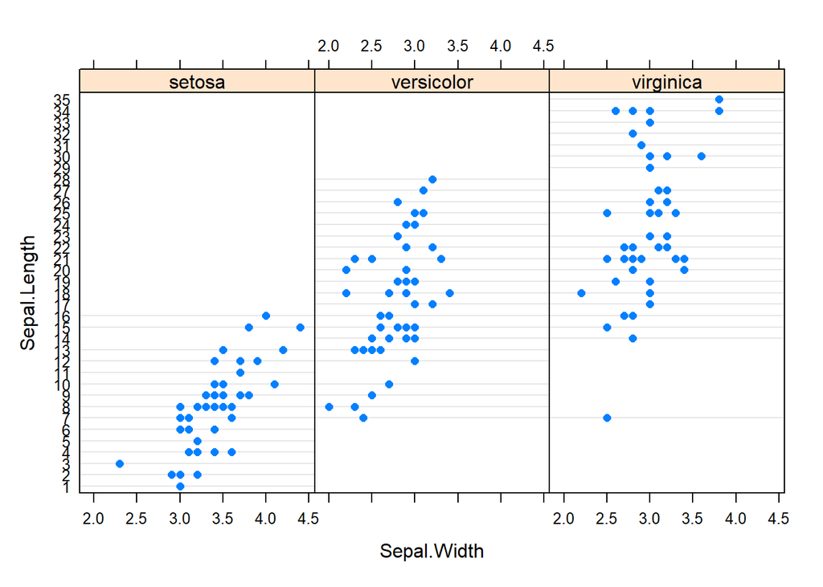

```r
# 점 그림
dotplot(Sepal.Length~Sepal.Width | Species)
```

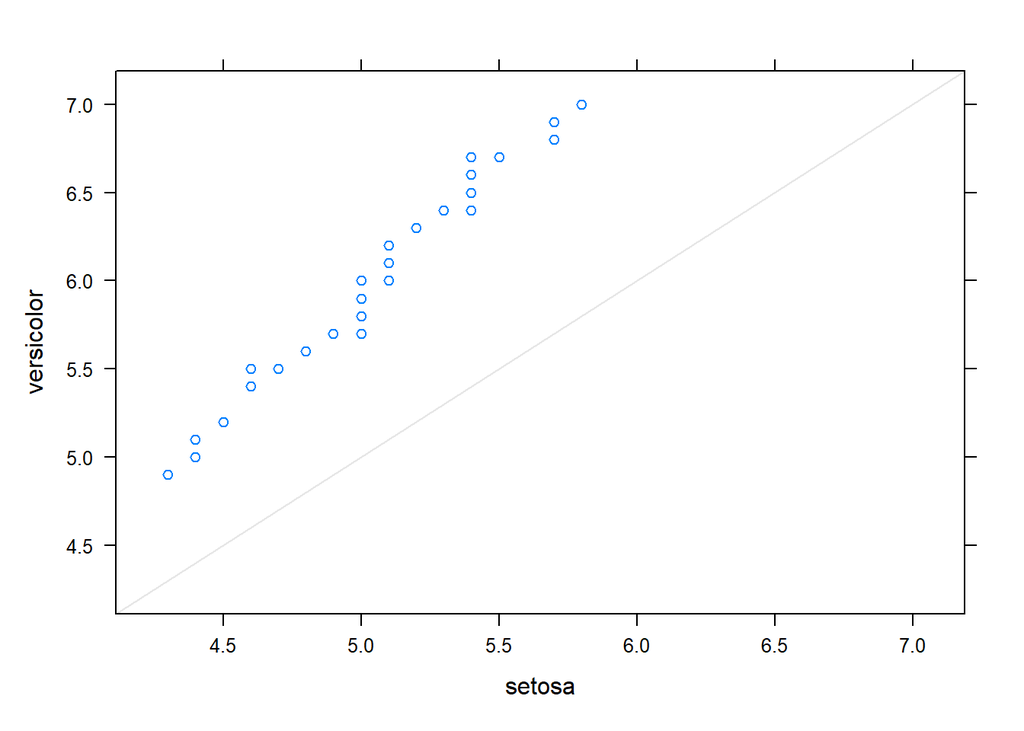

```r
## 두 개의 분포를 비교하기 위한 QQ 그림
qq(Species~Sepal.Length, subset=(Species=="setosa"| Species=="versicolor"))
```

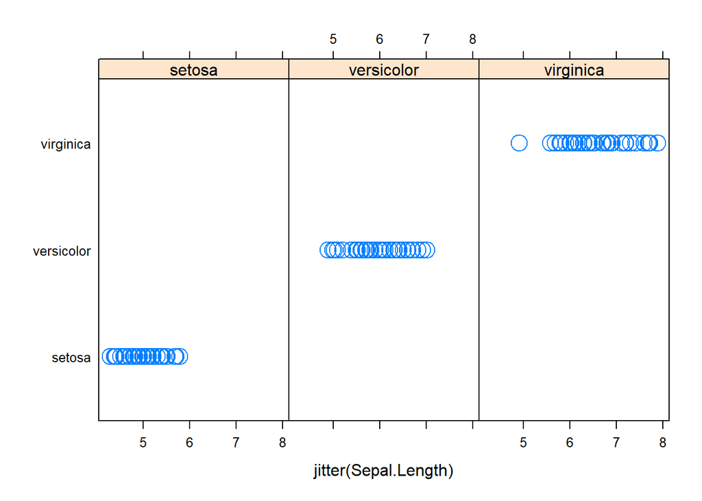

```r
# 띠 그림
stripplot(Species~jitter(Sepal.Length) | Species, cex=2)
```

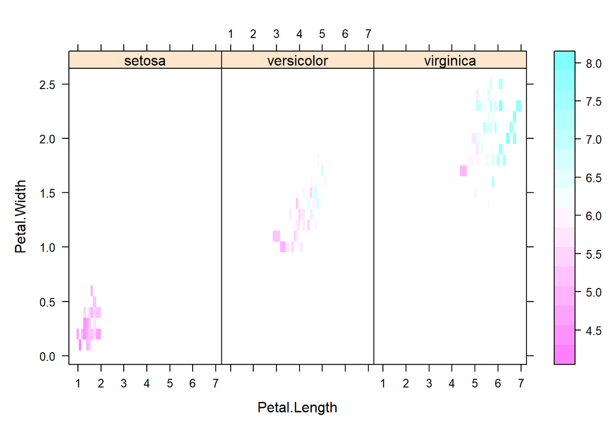

```r
# 수준 그림
levelplot(Sepal.Length~Petal.Length*Petal.Width | Species)
```

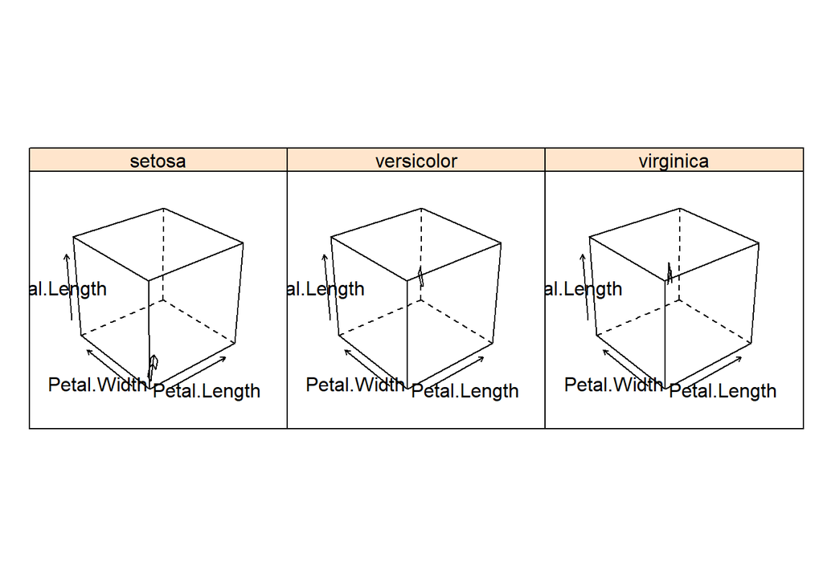

```r
# 철망형 그림
wireframe(Sepal.Length~Petal.Length*Petal.Width | Species)
```

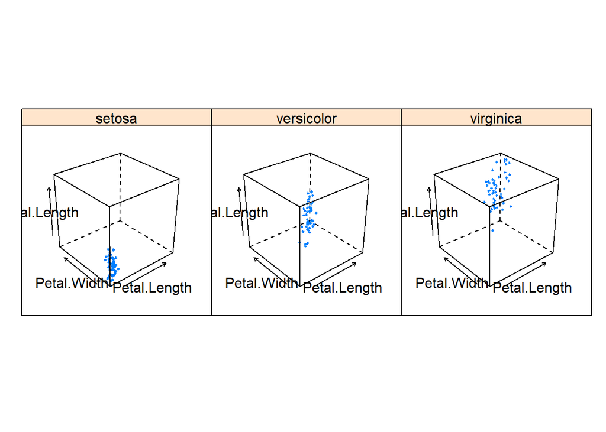

```r
# 구름형 그림
cloud(Sepal.Length~Petal.Length*Petal.Width | Species)
```

### 03.6 다중 그래픽스 : 그래픽 디바이스의 분할

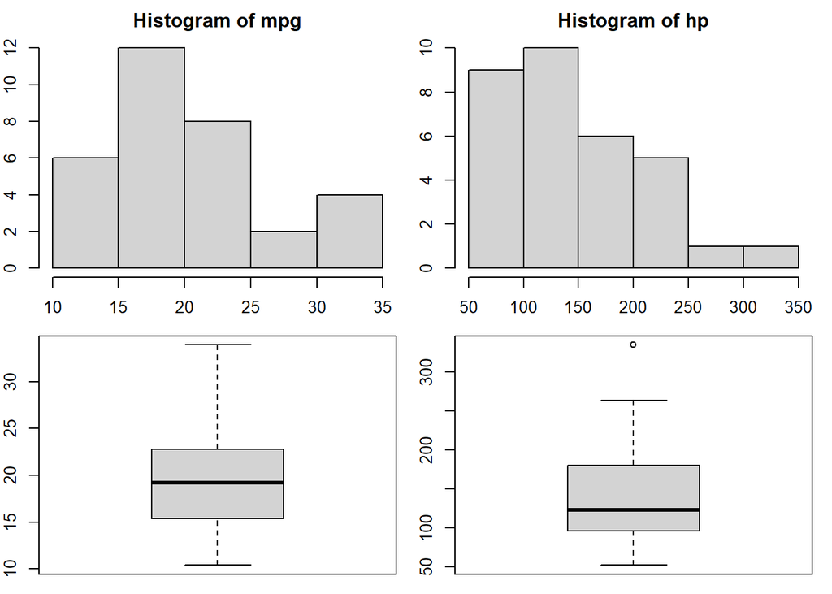

```r
#(a) par(mfrow=c()) 이용 예제
## 그래픽 디바이스 분할
attach(mtcars)
par(mfrow=c(2,2))  # 2행 2열의 형태로 지정, 행 우선으로 그림이 차례로 위치함.
par(mar=c(1, 2, 2, 1))  # 여백 지정
hist(mpg)  # 첫 번째 그림
hist(hp)  # 두 번째 그림
boxplot(mpg)  # 세 번째 그림
boxplot(hp)  # 네 번째 그림
```

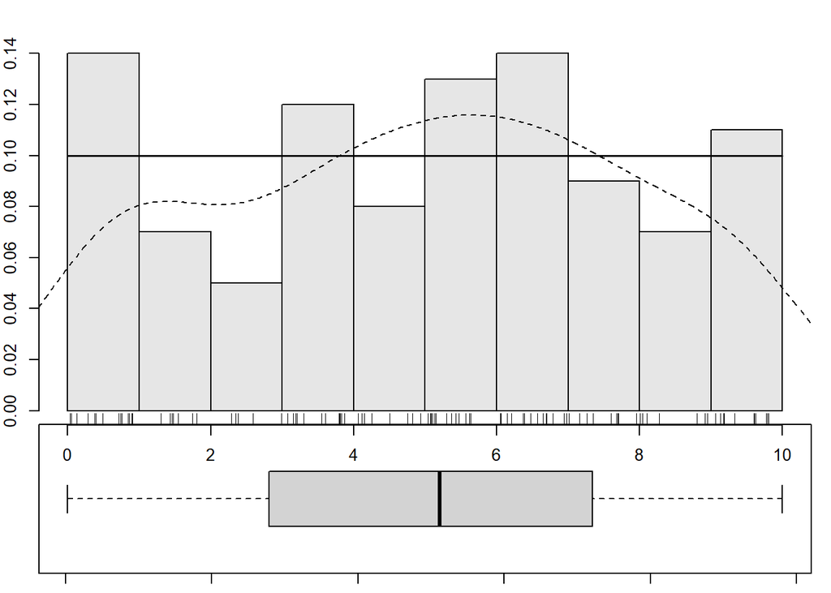

```r
#(b) par(fig=) 이용 예제
res <- runif(100, min=0, max=10)
## fig= 다음 그림의 영역을 하단 35%로 지정함
par(fig=c(0, 1, 0, .35))
boxplot(res, horizontal=TRUE, bty="n", xlab="Uniform Sample")
## fig= 다음 그림의 영역을 상단 75%에 위치시킴
par(fig=c(0, 1, .25, 1), new=TRUE)
hist(res, prob=TRUE, main="", col=gray(.9))
lines(density(res), lty=2)
curve(dunif(x, min=0, max=10), lwd=1.5, add=TRUE)
rug(res)
```

```r
#(c) layout() 함수 이용 예제
## 그래픽 디바이스 분할
layout(matrix(c(1, 0, 3, 2),  # 행렬의 번호는 그려질 그림의 순서임
              2, 2, byrow=TRUE),
       widths=c(3, 1),  # 1열 그림의 너비가 전체의 3/4 이도록
       heights=c(1, 3),  # 2행의 높이가 전체의 3/4 이도록
       respect=TRUE)  # 정사각형의 형태이도록
par(no.readonly = FALSE)
```

[output not shown]

[output not shown]

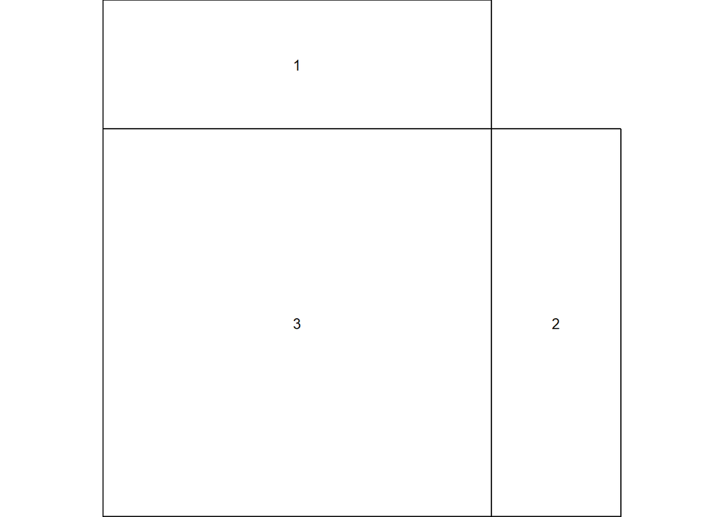

```r
mul <- layout(matrix(c(1, 0, 3, 2),  # 행렬의 번호는 그려질 그림의 순서임
              2, 2, byrow=TRUE),
       widths=c(3, 1),  # 1열 그림의 너비가 전체의 3/4 이도록
       heights=c(1, 3),  # 2행의 높이가 전체의 3/4 이도록
       respect=TRUE)  # 정사각형의 형태이도록
layout.show(mul)  # 분할된 그래픽 디바이스 형태
```

```r
## 여백 조정 후 그리기 위해 플롯 결과만 저장
attach(mtcars)
```

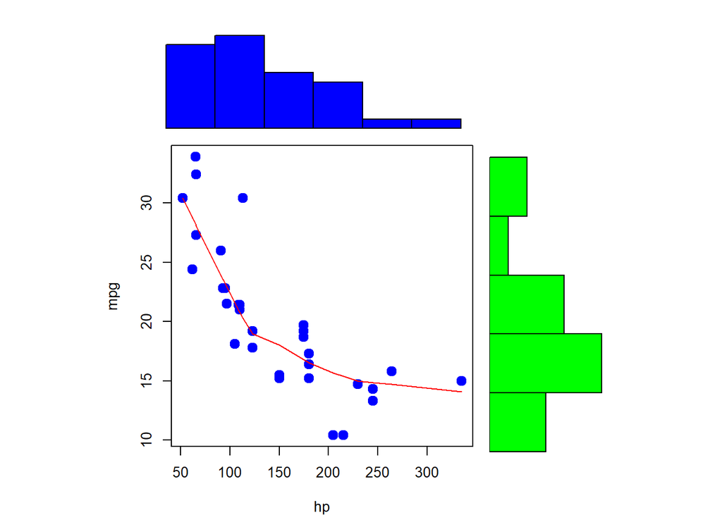

```r
xhist <- hist(hp, plot=FALSE)  # 마진 조정 후 그리기 위해 plot=FALSE로 지정
yhist <- hist(mpg, plot=FALSE)
top <- max(c(xhist$counts, yhist$counts))  # 히스토그램의 높이 최댓값을 저장
## 여백 조정 후 그림
par(mar=c(0, 3, 1, 1))  # 여백 조정
barplot(xhist$counts, axes=FALSE, ylim=c(0, top),  # 첫 번째 그림
        space=0, col="blue")
par(mar=c(3, 0, 1, 1))  # 여백 조정
barplot(yhist$counts, axes=FALSE, xlim=c(0, top),  # 두 번째 그림
        space=0, col="green", horiz=TRUE)
par(mar=c(4, 4, 1, 1))  # 여백 조정
plot(mpg ~ hp, pch=19, cex=1.5, col="blue")  # 세 번째 그림
lines(lowess(hp, mpg), col="red")  # 평활곡선 추가
```

```r
# ==  lines(supsmu(hp, mpg))
# == abline(lm(mpg ~ hp))

#(d) par() 함수 : 그래픽 옵션 변경
par.0 <- par(no.readonly = TRUE)  #읽기 전용이 아닌 그래픽 인자들만 저장해둠
par(par.0)
```